# Atividade 07 - Regressão Linear

Author

Affiliation

Grupo 3 (Malawi): Juliana Oliveira, Pedro H. de Araujo e Vitória Murakami

Graduate Program in Genetics and Plant Breeding, Department of Genetics, ESALQ-USP

# Regressão Linear

> Using the dataset of the project, perform linear regressions between traits, and between traits and environmental features. Choose some significant relationships to dissect and interpret their results. In your scripts, perform the regressions “manually” and using the “lm” function and its accessories. Feel free to explore other types of relationship in your regression models (polynomial, interactions, etc.).

## Introdução

### Modelo Estatístico

Entende-se como modelo em estatística, a representação matematica simplificada de fênomenos reais. Ele espressa a relação entre variáveis por meio de equações e parametros, gerando uma estrutura probabilistica, que permite simular resultados fazer inferências e testar hipóteses. Os modelos podem ser definidos por diferentes estratégias, utilizando estruturas mais ou menos rigidas, à depender do objetivo da análise, podendo ser construído à partir de pressupostos teóricos, suposições probabilisticas, relações funcionais, ou utilização de técnicas de aprendizado estatístico. Em todos os casos, a escolha do modelo é primordial e influência na natureza das inferências realizadas.

### Modelos Lineares

Um dos tipos de modelos mais utilizados em estatística, é a regressão- uma técnica que lança mão de princípios algébricos para modelar relações entre variáveis correlacionadas, comparando-as à padrões de funções matemáticas. No caso da regressão linear, por exemplo, o que o modelo faz, é basicamente traçar uma reta de forma à minimizar a distância entre os valores observados e os valores estimados. Outras regressões importantes incluem regressão logística, polinomial e multipla.

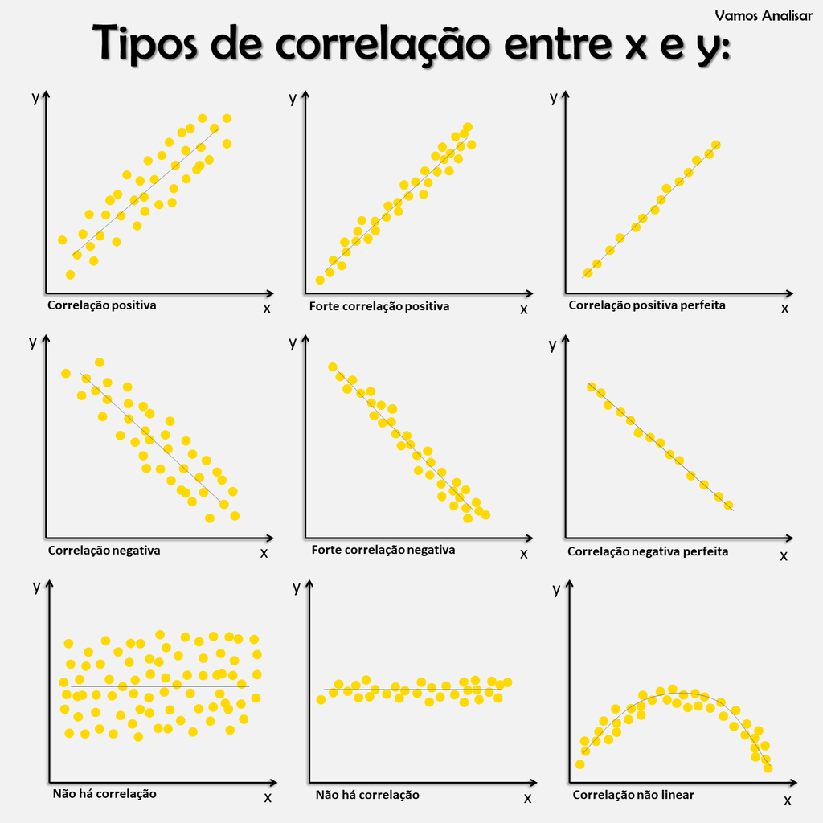

Tipos de correlação em variáveis dependentes

### Regressão Linear Simples

A regressão linear pode ser classificada em simples ou multiplas à depender do número de váriaveis preditoras envolvidas, àquelas que estudam a influência de apenas uma9 variável preditora por vez são chamadas simples, enquanto as que estudam a influência de multiplos fatores simultâneos recebem o nome de regressões multiplas. A presente seção tratará apenas das primeiras, entretanto, uma introdução mais aprofundada de regressões multiplas pode ser encontrado mais adiante no trabalho, em momento oportuno.

Um modelo linear simples de regressão pode ser definido de maneira geral por:
$$y_i = \beta_0+\beta_1x_1+\varepsilon_i \qquad i=1,2,3..., n$$
sendo: y= resposta (variável dependente) $\beta_0$ = Intercepto do modelo (espectativa de y quando x=0) $\beta_1$ = coeficiente angular da regressão x = preditor (variável independete) $\varepsilon_i$ efeito aleatório de erro (variação não explicada)

Para completar o modelo, devemos também considerar algumas suposições:
$$\begin{aligned}
E(\varepsilon_{ij}) &= 0 \quad \forall\, i,j \\
Var(\varepsilon_{ij}) &= \sigma^2 \quad \forall\, i,j \\
Cov(\varepsilon_{ij}, \varepsilon_{i'j'}) &= 0 \quad \forall\, i\neq i',\, j\neq j'
\end{aligned}$$

Qualquer uma dessas suposições pode não se confirmar quando se trabalha com dados reais, portanto, é importante que seja feita a verificação dos pressupostos previamente à análise;

Para iniciar as análises primeiro devemos importar os dados do github [Pan African Network](https://github.com/mauricioaraujj/Pan_African_Trials_Network). também aproveitamos para importar pacotes, e filtrar apenas os dados do Malawi, para optimizar o espaço de trabalho.

### Covariância entre características

Para calcular a covariância, selecionamos 5 características quantitativas continuas e uma quantitativa discreta, sendo produtividade de grãos a resposta, e emergencia de plântulas, altura de planta na maturidade, conteúdo de proteína no grão, conteúdo de óleo no grão e severidade de ferrugem, os preditores. A função drop_na() foi utilizada para descartar linhas com dados incompletos. Passamos a variavel resposta e os preditores para o formato matriz e em seguida realizamos o calculo com cov(XY)

$$\begin{bmatrix}
\text{GY}_{1} \\
\text{GY}_{2} \\
\text{GY}_{3} \\
\vdots \\
\text{GY}_{n}
\end{bmatrix}
\qquad$$

X_{1} =

$$\begin{bmatrix}
\text{Emerg}_{1} \\
\text{Emerg}_{2} \\
\text{Emerg}_{3} \\
\vdots \\
\text{Emerg}_{n}
\end{bmatrix}
\qquad$$

X_{2} =

$$\begin{bmatrix}
\text{Alt}_{1} \\
\text{Alt}_{2} \\
\text{Alt}_{3} \\
\vdots \\
\text{Alt}_{n}
\end{bmatrix}
\qquad$$

X_{3} =

$$\begin{bmatrix}
\text{Ferrugem}_{1} \\
\text{Ferrugem}_{2} \\
\text{Ferrugem}_{3} \\
\vdots \\
\text{Ferrugem}_{n}
\end{bmatrix}
\qquad$$

X_{4} =

$$\begin{bmatrix}
\text{Prot}_{1} \\
\text{Prot}_{2} \\
\text{Prot}_{3} \\
\vdots \\
\text{Prot}_{n}
\end{bmatrix}
\qquad$$

X_{5} =

$$\begin{bmatrix}
X5_{1} \\
X5_{2} \\
X5_{3} \\
\vdots \\
X5_{n}
\end{bmatrix}$$

```r
# Selecionando as variáveis
XY <- data.frame(df |>
                  select(c(PL_EMERG_COUNT, PH_R8, R6_RUST_Sev, PROT, OIL, GY)) |>
                    drop_na())

Y <- as.matrix(XY[,6]) # Grain Yield (Variável resposta)
X1 <- as.matrix(XY[,1]) # Plant emergence - plants/plot (Variável regressora 1)
X2 <- as.matrix(XY[,2]) # Plant height at maturity - cm (Variável regressora 2)
X3 <- as.matrix(XY[,3]) # Rust severity - 1~5 scale (Variável regressora 3)
X4 <- as.matrix(XY[,4]) # Seed protein content - g/kg (Variável regressora 4)
X5 <- as.matrix(XY[,5]) # Seed oil content - g/kg (Variável regressora 5)

# Covariância
round(cov(XY),2)
```

```
               PL_EMERG_COUNT    PH_R8 R6_RUST_Sev   PROT     OIL         GY
PL_EMERG_COUNT        6684.96   231.52       -4.38  24.40    7.18   23367.59
PH_R8                  231.52  1049.95        9.66  28.45  -10.87   11102.24
R6_RUST_Sev             -4.38     9.66        0.98   0.82   -0.45     142.64
PROT                    24.40    28.45        0.82  12.83   -4.78     532.58
OIL                      7.18   -10.87       -0.45  -4.78    3.24    -167.44
GY                   23367.59 11102.24      142.64 532.58 -167.44 1258502.68
```

### Correlação entre características

A correlação, assim como a covariância ajuda a verificar relações entre variáveis. A grande diferença é que, enquanto a covariância não tem escala fixa, seus resultados variando muito em função de unidade, a correlação é padronizada em uma escala que vai de -1 a 1, e podemos facilmente interpreta-la: valores de 0 à 0,19 a correlação é considerada ínfima ou desprrezivel, de 0,20 a 0,39 correlação fraca, 0,40 à 0,59 moderada, 0,60 à 0,79 forte, e acima de 0,8 muito forte. os valores também podem assumir valores negativos, o que indica que as váriaveis apresentam comportamentos inversos, enquanto uma aumenta, a outra reduz, proporcionalmente.

```r
# Correlação
round(cor(XY),2)
```

```
               PL_EMERG_COUNT PH_R8 R6_RUST_Sev  PROT   OIL    GY
PL_EMERG_COUNT           1.00  0.09       -0.05  0.08  0.05  0.25
PH_R8                    0.09  1.00        0.30  0.25 -0.19  0.31
R6_RUST_Sev             -0.05  0.30        1.00  0.23 -0.25  0.13
PROT                     0.08  0.25        0.23  1.00 -0.74  0.13
OIL                      0.05 -0.19       -0.25 -0.74  1.00 -0.08
GY                       0.25  0.31        0.13  0.13 -0.08  1.00
```

A partir dessa matriz de correlações podemos observar que todas as variáveis possuem uma correlação positiva e negativas, variando de -0.74 à 0.31. Ou seja, quando há o aumento em uma variável também há nas outras, e se houver a diminuição de uma as outras também diminuem. Com as variáveis de correlação negativa acontece o inverso, quando uma variável aumenta a outra diminuiria. Nesse caso, a produção de grãos (GY/$y$) apresenta uma maior correlação com a altura da planta madura (PH_R8/$x_2$), com 0.31 e com a emergência da planta ($x_1$), com valor de 0.25. Dessa forma, as variáveis $x_2$ e $x_1$ as melhores preditoras do modelo que busca explicar produtividade de grãos.

Além disso, observa-se que as variáveis teor de proteína e óleo possuem correlação negativa($-0.74$). E que a correlação das variáveis entre si tem baixa correlação, portanto, considerando um modelo de regressão múltipla essas variáveis podem estar salvas de problemas de multicolineariedade.

### Regressão entre todas características para GY

à partir desse momento, utilizaremos regressões multiplas.Um tipo de modelagem utilizada quando se deseja avaliar simultaneamente o efeito de duas ou mais variáveis preditoras sobre uma variável resposta.a regressão múltipla permite incorporar diferentes fontes de variação ao modelo, mostrando o efeito parcial de cada variável sobre o resultado final, quando as demais são constantes:

Podemos ajustar o modelo de regressão $y_{ij} = \beta_0 + \beta_1x_{i1} + \beta_2x_{i2} + \beta_3x_{i3} + \beta_4x_{i4} + \beta_5x_{i5}$ e encontrar os estimadores ($\beta_0$, $\beta_1$, $\beta_2$, $\beta_3$, $\beta_4$, $\beta_5$) através dos quadrados mínimos. Em que:

- $\beta_0$: intercepto;
- $x_{i1}$: observações da variável regressora $\beta_1$, *Plant emergence (plants/plot)*;
- $x_{i2}$: observações da variável regressora $\beta_2$, *Plant height at maturity (cm)*;
- $x_{i3}$: observações da variável regressora $\beta_3$, *Rust severity (1~5 scale)*;
- $x_{i4}$: observações da variável regressora $\beta_4$, *Seed protein content (g/kg)*;
- $x_{i5}$: observações da variável regressora $\beta_5$, *Seed oil content (g/kg)*;

E os $\beta \text{'s}$ são calculados matricialmente por: $\hat{\beta} = (X'X)^{-1}Xy$.

```r
# Regressão
# Usando todas as variáveis
X <- as.matrix(cbind(1, X1, X2, X3, X4, X5))
XlX = crossprod(X)
XlY = crossprod(X, Y)

## Encontrando os betas
betas = solve(XlX) %*% XlY
rownames(betas) <- paste0('B', 0:5); round(betas, 3) # Alterando o nome da coluna
```

```
       [,1]
B0 1476.238
B1    3.197
B2    8.995
B3   60.595
B4    9.168
B5   -6.605
```

Também é possível estimar os $\beta \text{'s}$ através de função `lm()` do R. Vamos conferir se os resultados são iguais.

```r
## Usando a função lm
lm.1 <- lm(GY ~ PL_EMERG_COUNT + PH_R8 + R6_RUST_Sev + PROT + OIL, data = df); round(lm.1$coefficients,3)
```

```
   (Intercept) PL_EMERG_COUNT          PH_R8    R6_RUST_Sev           PROT
      1476.238          3.197          8.995         60.595          9.168
           OIL
        -6.605
```

Assim tenho que:
$$\hat{y_{ij}} = 1476.238 + 3.197x_{i1} + 8.995x_{i2} + 60.595_3x_{i3} + 9.168x_{i4} -6.605x_{i5}$$

Considerando o modelo especificado, tem-se que:

- para cada planta que emerge a mais por parcela ($x_1$) espera-se um *aumento* na produção de grãos ($y$) em 3.197, se as outras variáveis forem mantidas constantes ($x_2$, $x_3$, $x_4$, $x_5$);
- para cada centímetro a mais na altura da planta ($x_2$) espera-se um *aumento* na produção de grãos ($y$) de 8.995, se as outras variáveis ($x_1$, $x_3$, $x_4$, $x_5$) forem mantidas constantes;
- para cada ponto a mais dado na severidade da ferrugem ($x_3$) espera-se um *aumento* na produção de grãos ($y$) de 60.595, se as outras variáveis ($x_2$, $x_3$, $x_4$, $x_5$) forem mantidas constantes;
- para cada grama a mais em conteúdo de proteína ($x_4$) espera-se um *aumento* na produção de grãos ($y$) de 9.168, se as outras variáveis ($x_1$, $x_2$, $x_3$, $x_4$) forem mantidas constantes;
- para cada grama a mais em conteúdo de óleo ($x_5$) espera-se um *decréscimo* na produção de grãos ($y$) de 6.605, se as outras variáveis ($x_1$, $x_2$, $x_3$, $x_4$) forem mantidas constantes;

Para realizar o **teste de significância** do modelo vamos testar a hipótese $H_0: \beta_1= \beta_2 = \beta_3 = \beta_4 = \beta_5$. A hipótese alternativa é que pelo menos um dos $\beta \text{'s}$ não é nulo, ou que pelo menos uma das variáveis $x \text{'s}$ é importante na predição da produção de grãos ($y$).

Para realizar o teste eu preciso da soma de quadrados de resíduos e da soma de quadrados da regressão. Sendo que:

- Soma de quadrados totais = $y'y = y'\left( I - \frac{1}{n} \right)y$, e tem $n-1$ graus de liberdade, onde n é o número de observações;
- Soma de quadrados de resíduos = $y'y - \hat{\beta}'X'y = y'\left[ I - X(X'X)^{-1} \right]y$, com $(n - k -1)$ graus de liberdade, onde k é o número de parâmetros ($\beta \text{'s}$);
- Soma de quadrados da regressão = $\hat{\beta}'X'y - n\bar{y}^2 = y'\left[X(X'X)^{-1}X' - \frac{1}{n}J \right]y$, com $(k)$ graus de liberdade, onde k é o número de parâmetros ($\beta \text{'s}$);

E então fazemos a estatística F, em que:

$$F = \frac{\text{QMRegressão}}{\text{QMResíduo}}$$
E rejeitamos $H_0: \beta_1 = \beta_2 = \beta_3 = \beta_4 = \beta_5$ caso F > F($\alpha$, k, n-k-1) ou p-valor < 0.05.

```r
n <- nrow(Y) # número de observações
k <- qr(X)$rank - 1
I <- diag(n) # Matriz identidade
J <- matrix(1, nrow = n, ncol = n) # Matriz de 1's
j <- matrix(1, nrow = n, byrow = T) # Vetor de 1's

# Soma de quadrados totais
SQtotal <- t(Y) %*% (I - (1/n*J)) %*% Y
gl_total <- n - 1

# Soma de quadrados da regressão
SQreg <- t(Y)%*%(X%*%solve(t(X)%*%X)%*%t(X) - (1/n*J))%*%Y
gl_reg <- k

# Soma de quadrados de resíduos
SQres <- t(Y)%*%(I-X%*%solve(t(X)%*%X)%*%t(X))%*%Y
gl_res <- n - k - 1

# F calculado
Fcal = (SQreg/gl_reg)/(SQres/gl_res)

# p-valor
p_valor <- pf(Fcal, k, n-k-1, lower.tail = F)

# Quadro ANOVA
QAnova <- data.frame(FV = c("Regressão", "Resíduos", "Total"),
                     GL = c(gl_reg, gl_res, gl_total),
                     SQ = c(SQreg, SQres, SQtotal),
                     'F' = c(round(Fcal, 3), '-', '-'),
                     p = c(round(p_valor,3), '-', '-'))

knitr::kable(QAnova,
      col.names = c("Fator de Variação", "Graus de liberdade", "Soma de Quadrados", "F", "p valor"),
      align = "ccccc",
      digits = 4,
      caption = "legenda")
```

legenda

| Fator de Variação | Graus de liberdade | Soma de Quadrados | F | p valor |
| --- | --- | --- | --- | --- |
| Regressão | 5 | 717091011 | 133.947 | 0 |
| Resíduos | 3785 | 4052634159 | - | - |
| Total | 3790 | 4769725170 | - | - |

Também podemos obter essas estimativas chamando o `summary` do modelo ajustado pela função `lm`.

```r
summary(lm.1)
```

```
Call:
lm(formula = GY ~ PL_EMERG_COUNT + PH_R8 + R6_RUST_Sev + PROT +
    OIL, data = df)

Residuals:
    Min      1Q  Median      3Q     Max
-2929.3  -727.4   -65.0   658.4  5783.7

Coefficients:
                Estimate Std. Error t value Pr(>|t|)
(Intercept)    1476.2383   554.0027   2.665 0.007739 **
PL_EMERG_COUNT    3.1974     0.2104  15.200  < 2e-16 ***
PH_R8             8.9946     0.5565  16.163  < 2e-16 ***
R6_RUST_Sev      60.5952    18.2946   3.312 0.000934 ***
PROT              9.1677     7.2036   1.273 0.203220
OIL              -6.6054    14.2424  -0.464 0.642829
---
Signif. codes:  0 '***' 0.001 '**' 0.01 '*' 0.05 '.' 0.1 ' ' 1

Residual standard error: 1035 on 3785 degrees of freedom
  (3396 observations deleted due to missingness)
Multiple R-squared:  0.1503,    Adjusted R-squared:  0.1492
F-statistic: 133.9 on 5 and 3785 DF,  p-value: < 2.2e-16
```

Obtemos os mesmo valores da estatítica F e p-valor, tanto matricialmente quanto pela função do R. Como obtivemos um p-valor < 0.05, rejeitamos a hipótese $H_0$ a um nível de 5% de significância, e concluímos que pelo menos uma das variáveis preditoras ($x_1$, $x_2$, $x_3$, $x_4$ e $x_5$) do modelo de regressão é importante na predição de $y$ e, portanto, deve ser mantida no modelo.

```r
# R2
R2 <- SQreg/SQtotal

# R2 ajustado
R2aj <- ((n-1)*(SQreg/SQtotal)-k)/(n-k-1)

tabela <- data.frame(Metrica = c("R^2^", "R^2^ Ajustado"),
                     `Matricialmente` = c(R2, R2aj),
                     `lm()` = c(summary(lm.1)$r.squared, summary(lm.1)$adj.r.squared))

knitr::kable(tabela,
             col.names = c("Metrica", "Matricialmente", "Função lm()"),
             align = "ccc",
             digits = 4)
```

| Metrica | Matricialmente | Função lm() |
| --- | --- | --- |
| R<sup>2</sup> | 0.1503 | 0.1503 |
| R<sup>2</sup> Ajustado | 0.1492 | 0.1492 |

O coeficiente de determinação ajustado encontrado indica que $14.92\%$ da variação de $Y$ é explicada pelo modelo.

Também podemos conferir o ajuste do modelo através de alguns gráficos, por exemplo:

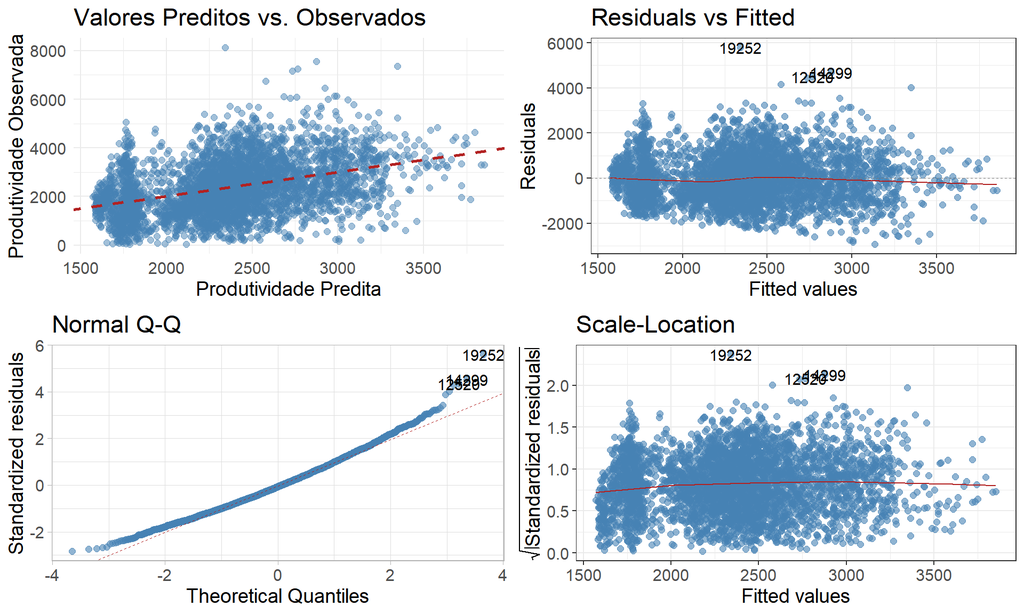

```r
# Cálculo matricial das predições
Y_pred <- X %*% betas

# Criando um data frame para o plot
df_residuos <- data.frame(Observado = as.numeric(Y),
                          Predito = as.numeric(Y_pred))

p0_lm.1 <- df_residuos |> ggplot(aes(x = Predito, y = Observado)) +
  geom_point(color = "steelblue", alpha = 0.5, size = 2) +
  geom_abline(intercept = 0, slope = 1, color = "firebrick", linetype = "dashed", size = 1) +
  labs(
    title = "Valores Preditos vs. Observados",
    x = "Produtividade Predita",
    y = "Produtividade Observada") +
  theme_minimal() +
  theme(text = element_text(size = 14))

## Gráficos do ajuste
p1_lm.1 <- autoplot(lm.1,
                    which = 1,
                    nrow = 1,
                    ncol = 1,
                    colour = 'steelblue',    # Cor dos pontos (resíduos)
                    smooth.colour = 'firebrick', # Cor da linha de tendência (curva)
                    ad.colour = 'grey50',    # Cor da linha horizontal de referência (zero)
                    size = 2,
                    line.size = 1,
                    alpha = 0.6) +
  theme_bw() +
  theme(text = element_text(size = 14))

p2_lm.1 <- autoplot(lm.1,
                    which = 2,
                    nrow = 1,
                    ncol = 1,
                    colour = 'steelblue',    # Cor dos pontos (observações)
                    ad.colour = 'firebrick', # Cor da linha de referência (Q-Q line)
                    ad.linetype = 'dashed',  # Estilo da linha
                    size = 2,                # Tamanho dos pontos
                    alpha = 0.6) +           # Transparência dos pontos
  theme_light() +
  theme(text = element_text(size = 14))

p3_lm.1 <- autoplot(lm.1,
                    which = 3,
                    nrow = 1,
                    ncol = 1,
                    colour = 'steelblue',       # Cor dos pontos (resíduos padronizados)
                    smooth.colour = 'firebrick',    # Cor da linha de tendência
                    ad.colour = 'grey50',       # Cor da linha de referência
                    size = 2,
                    alpha = 0.6) +
  theme_bw() +
  theme(text = element_text(size = 14))

grid.arrange(p0_lm.1, p1_lm.1[[1]], p2_lm.1[[1]], p3_lm.1[[1]], ncol = 2)
```

Quando observamos o grafico da regressão, e no gráfico de resíduos, fica perceptível uma grande variância nas observações, isso ocorre em boa parte, por estarmos analisando uma base proveniente de ensaios multiambientes, sujeitos à grandes efeitos ambientais e efeitos de interação genótipo ambiente, que não são capturados pelo modelo. Ademais, apesar de os dados apresentarem resíduos considerados normais, as caudas da distribuição desviam dos valores esperados. A presença de outliers, destacada em todos os gráficos, atrapalham o modelo, futuramente, é interessante que se faça o tratamento destes outliers para melhorar a qualidade da inferência.

- Variância dos resíduos:

```r
## Variância dos resíduos (sigma^2)
n = length(Y)
I = diag(nrow = n)
rX = qr(X)$rank
H = X %*% solve(XlX) %*% t(X)
SSresid = t(Y) %*% (I - H) %*% Y
df_res = n-rX
sigma2 = SSresid/df_res; sigma2 # matricialmente
```

```
        [,1]
[1,] 1070709
```

```r
sum(lm.1$residuals^2)/lm.1$df.residual # com lm
```

```
[1] 1070709
```

Nesse modelo foram utilizadas cinco variáveis preditoras para explicar a produtividade de grãos (GY). Entretanto, é possível que algumas dessas variáveis contribuam pouco para a capacidade explicativa do modelo, tornando sua permanência desnecessária. A inclusão excessiva de variáveis pode resultar em problemas de superparametrização, dessa forma, foi seleção *stepwise*, que avalia diferentes combinações de preditores com o objetivo de identificar o modelo que melhor explica a variável resposta.

```r
# Seleção de variáveis
stepwise_model <- step(lm(Y ~ 1, data = XY),
                       scope = list(lower = ~1, # lower = de onde começar; upper até onde parar
                                    upper = ~ X1 + X2 + X3 + X4 + X5),
                       direction = "both", # direção
                       trace = 0) # mostra passo a passo, se não quiser ver ‘trace = 0’

summary(stepwise_model)
```

```
Call:
lm(formula = Y ~ X2 + X1 + X3 + X4, data = XY)

Residuals:
    Min      1Q  Median      3Q     Max
-2934.8  -727.3   -66.4   658.1  5774.7

Coefficients:
             Estimate Std. Error t value Pr(>|t|)
(Intercept) 1235.4368   193.2151   6.394 1.81e-10 ***
X2             8.9913     0.5564  16.160  < 2e-16 ***
X1             3.1821     0.2078  15.317  < 2e-16 ***
X3            61.5758    18.1702   3.389 0.000709 ***
X4            11.6049     4.9267   2.355 0.018549 *
---
Signif. codes:  0 '***' 0.001 '**' 0.01 '*' 0.05 '.' 0.1 ' ' 1

Residual standard error: 1035 on 3786 degrees of freedom
Multiple R-squared:  0.1503,    Adjusted R-squared:  0.1494
F-statistic: 167.4 on 4 and 3786 DF,  p-value: < 2.2e-16
```

## 4 características

Portanto, podemos retirar a variável *Seed oil content*. Vamos refazer as contas com o modelo:

$$y_{ij} = \beta_0 + \beta_1x_{i1} + \beta_2x_{i2} + \beta_3x_{i3} + \beta_4x_{i4}$$

```r
# Usando as variáveis 1 a 4
X <- as.matrix(cbind(1, X1, X2, X3, X4))

## Encontrando os betas
betas <- solve(t(X)%*%X)%*%t(X)%*%Y # B = XLXXLy
rownames(betas) <- paste0('B', 0:4); round(betas, 3) # Alterando o nome da coluna
```

```
       [,1]
B0 1235.437
B1    3.182
B2    8.991
B3   61.576
B4   11.605
```

```r
## Usando a função lm
lm.2 <- lm(GY ~ PL_EMERG_COUNT + PH_R8 + R6_RUST_Sev + PROT, data = df); round(lm.2$coefficients,3)
```

```
   (Intercept) PL_EMERG_COUNT          PH_R8    R6_RUST_Sev           PROT
      1235.437          3.182          8.991         61.576         11.605
```

```r
n <- nrow(Y) # número de observações
k <- qr(X)$rank - 1
I <- diag(n) # Matriz identidade
J <- matrix(1, nrow = n, ncol = n) # Matriz de 1's
j <- matrix(1, nrow = n, byrow = T) # Vetor de 1's

# Soma de quadrados totais
SQtotal <- t(Y) %*% (I - (1/n*J)) %*% Y
gl_total <- n - 1

# Soma de quadrados da regressão
SQreg <- t(Y)%*%(X%*%solve(t(X)%*%X)%*%t(X) - (1/n*J))%*%Y
gl_reg <- k

# Soma de quadrados de resíduos
SQres <- t(Y)%*%(I-X%*%solve(t(X)%*%X)%*%t(X))%*%Y
gl_res <- n - k - 1

# F calculado
Fcal = (SQreg/gl_reg)/(SQres/gl_res)

# p-valor
p_valor <- pf(Fcal, k, n-k-1, lower.tail = F)

# Quadro ANOVA
QAnova <- data.frame(FV = c("Regressão", "Resíduos", "Total"),
                     GL = c(gl_reg, gl_res, gl_total),
                     SQ = c(SQreg, SQres, SQtotal),
                     'F' = c(round(Fcal, 3), '-', '-'),
                     p = c(round(p_valor,3), '-', '-'))

knitr::kable(QAnova,
      col.names = c("Fator de Variação", "Graus de liberdade", "Soma de Quadrados", "F", "p valor"),
      align = "ccccc",
      digits = 4,
      caption = "legenda")
```

legenda

| Fator de Variação | Graus de liberdade | Soma de Quadrados | F | p valor |
| --- | --- | --- | --- | --- |
| Regressão | 4 | 716860706 | 167.415 | 0 |
| Resíduos | 3786 | 4052864464 | - | - |
| Total | 3790 | 4769725170 | - | - |

```r
## R Check
summary(lm.2)
```

```
Call:
lm(formula = GY ~ PL_EMERG_COUNT + PH_R8 + R6_RUST_Sev + PROT,
    data = df)

Residuals:
    Min      1Q  Median      3Q     Max
-2934.8  -727.3   -66.4   658.1  5774.7

Coefficients:
                Estimate Std. Error t value Pr(>|t|)
(Intercept)    1235.4368   193.2151   6.394 1.81e-10 ***
PL_EMERG_COUNT    3.1821     0.2078  15.317  < 2e-16 ***
PH_R8             8.9913     0.5564  16.160  < 2e-16 ***
R6_RUST_Sev      61.5758    18.1702   3.389 0.000709 ***
PROT             11.6049     4.9267   2.355 0.018549 *
---
Signif. codes:  0 '***' 0.001 '**' 0.01 '*' 0.05 '.' 0.1 ' ' 1

Residual standard error: 1035 on 3786 degrees of freedom
  (3396 observations deleted due to missingness)
Multiple R-squared:  0.1503,    Adjusted R-squared:  0.1494
F-statistic: 167.4 on 4 and 3786 DF,  p-value: < 2.2e-16
```

```r
# R2
R2 <- SQreg/SQtotal

# R2 ajustado
R2aj <- ((n-1)*(SQreg/SQtotal)-k)/(n-k-1)

tabela <- data.frame(Metrica = c("R^2^", "R^2^ Ajustado"),
                     `Matricialmente` = c(R2, R2aj),
                     `lm()` = c(summary(lm.2)$r.squared, summary(lm.2)$adj.r.squared))

knitr::kable(tabela,
             col.names = c("Metrica", "Matricialmente", "Função lm()"),
             align = "ccc",
             digits = 4)
```

| Metrica | Matricialmente | Função lm() |
| --- | --- | --- |
| R<sup>2</sup> | 0.1503 | 0.1503 |
| R<sup>2</sup> Ajustado | 0.1494 | 0.1494 |

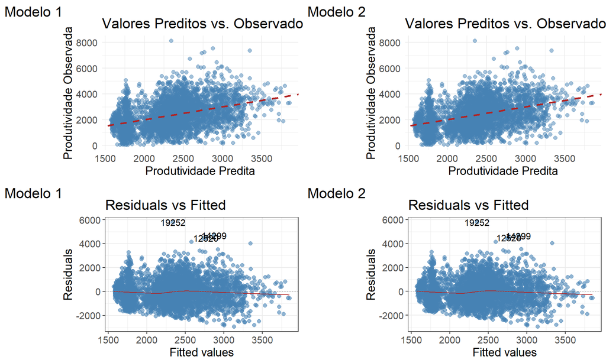

```r
# Cálculo matricial das predições
Y_pred <- X %*% betas

# Criando um data frame para o plot
df_residuos <- data.frame(Observado = as.numeric(Y),
                          Predito = as.numeric(Y_pred))

p0_lm.2 <- df_residuos |> ggplot(aes(x = Predito, y = Observado)) +
  geom_point(color = "steelblue", alpha = 0.5, size = 2) +
  geom_abline(intercept = 0, slope = 1, color = "firebrick", linetype = "dashed", size = 1) +
  labs(
    title = "Valores Preditos vs. Observados",
    x = "Produtividade Predita",
    y = "Produtividade Observada") +
  theme_minimal() +
  theme(text = element_text(size = 14))

## Gráficos do ajuste
p1_lm.2 <- autoplot(lm.2,
                    which = 1,
                    nrow = 1,
                    ncol = 1,
                    colour = 'steelblue',    # Cor dos pontos (resíduos)
                    smooth.colour = 'firebrick', # Cor da linha de tendência (curva)
                    ad.colour = 'grey50',    # Cor da linha horizontal de referência (zero)
                    size = 2,
                    line.size = 1,
                    alpha = 0.6) +
  theme_bw() +
  theme(text = element_text(size = 14))

p2_lm.2 <- autoplot(lm.2,
                    which = 2,
                    nrow = 1,
                    ncol = 1,
                    colour = 'steelblue',    # Cor dos pontos (observações)
                    ad.colour = 'firebrick', # Cor da linha de referência (Q-Q line)
                    ad.linetype = 'dashed',  # Estilo da linha
                    size = 2,                # Tamanho dos pontos
                    alpha = 0.6) +           # Transparência dos pontos
  theme_light() +
  theme(text = element_text(size = 14))

p3_lm.2 <- autoplot(lm.2,
                    which = 3,
                    nrow = 1,
                    ncol = 1,
                    colour = 'steelblue',       # Cor dos pontos (resíduos padronizados)
                    smooth.colour = 'firebrick',    # Cor da linha de tendência
                    ad.colour = 'grey50',       # Cor da linha de referência
                    size = 2,
                    alpha = 0.6) +
  theme_bw() +
  theme(text = element_text(size = 14))

grid.arrange(p0_lm.1 + labs(tag ="Modelo 1"), p0_lm.2 + labs(tag ="Modelo 2"),
             p1_lm.1[[1]] + labs(tag ="Modelo 1"), p1_lm.2[[1]] + labs(tag ="Modelo 2"), ncol = 2)
```

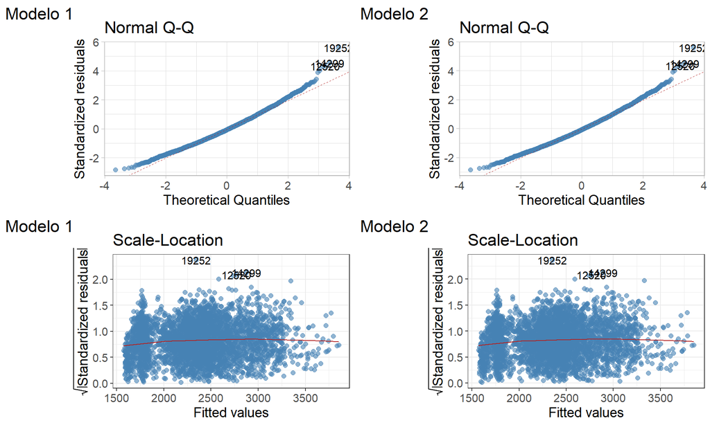

```r
grid.arrange(p2_lm.1[[1]] + labs(tag ="Modelo 1"), p2_lm.2[[1]] + labs(tag ="Modelo 2"),
             p3_lm.1[[1]] + labs(tag ="Modelo 1"), p3_lm.2[[1]] + labs(tag ="Modelo 2"), ncol = 2)
```

## Variáveis ambientais

Além das características fenotípicas podemos modelar regressões para variáveis ambientais. Foram escolhidas para esse teste, as variáveis Latitude, Longitude e Altitude, para partirmos da hipótese prévia que elas são relacionadas e tem influência na produtividade de grãos. Podemos portanto, ajustar o modelo de regressão $y_{ij} = \beta_0 + \beta_1x_{i1} + \beta_2x_{i2} + \beta_3x_{i3}$ e encontrar os estimadores ($\beta_0$, $\beta_1$, $\beta_2$, $\beta_3$) através dos quadrados mínimos. Em que:

- $y_{ij}$: variável resposta *produtividade de grãos (kg/ha)*;
- $\beta_0$: intercepto;
- $x_{i1}$: observações da variável regressora $\beta_1$, *Latitude (graus)*;
- $x_{i2}$: observações da variável regressora $\beta_2$, *Longitude (graus)*;
- $x_{i3}$: observações da variável regressora $\beta_3$, *Elevação (m)*.

E os $\beta \text{'s}$ são calculados matricialmente por: $\hat{\beta} = (X'X)^{-1}Xy$.

```r
# Selecionando as variáveis
XY <- data.frame(df |>
                  select(c(LAT, LON, ELEV, GY)) |>
                    drop_na())

Y <- as.matrix(XY[,4]) # Grain Yield (Variável resposta)
X1 <- as.matrix(XY[,1]) # Latitude - graus (Variável regressora 1)
X2 <- as.matrix(XY[,2]) # Longitude - graus (Variável regressora 2)
X3 <- as.matrix(XY[,3]) # Elevação - m (Variável regressora 3)

# Usando todas as variáveis
X <- as.matrix(cbind(1, X1, X2, X3))
XlX = crossprod(X)
XlY = crossprod(X, Y)

## Encontrando os betas
betas = solve(XlX) %*% XlY
rownames(betas) <- paste0('B', 0:3); round(betas, 3) # Alterando o nome da coluna
```

```
       [,1]
B0 6542.654
B1 -205.563
B2 -212.630
B3    0.347
```

Também é possível estimar os $\beta \text{'s}$ através de função `lm()` do R.

```r
## Usando a função lm
lm.3 <- lm(GY ~ LAT + LON + ELEV, data = df); round(lm.3$coefficients,3)
```

```
(Intercept)         LAT         LON        ELEV
   6542.654    -205.563    -212.630       0.347
```

A partir dos resultados do modelo de regressão, obtém-se a seguinte equação ajustada:

$$\hat{y}_{ij} = 6542.654 - 205.563x_{i1} - 212.630x_{i2} + 0.347x_{i3}$$
na qual: $x_{i1}$= Latitude, $x_{i2}$ Longitude $x_{i3}$= Elevação. e $\beta_0 = 6542.654$ intercepto do modelo, ou seja valor esperado quando em latitude e longitude 0.

```r
n <- nrow(Y) # número de observações
k <- qr(X)$rank - 1
I <- diag(n) # Matriz identidade
J <- matrix(1, nrow = n, ncol = n) # Matriz de 1's
j <- matrix(1, nrow = n, byrow = T) # Vetor de 1's

# Soma de quadrados totais
SQtotal <- t(Y) %*% (I - (1/n*J)) %*% Y
gl_total <- n - 1

# Soma de quadrados da regressão
SQreg <- t(Y)%*%(X%*%solve(t(X)%*%X)%*%t(X) - (1/n*J))%*%Y
gl_reg <- k

# Soma de quadrados de resíduos
SQres <- t(Y)%*%(I-X%*%solve(t(X)%*%X)%*%t(X))%*%Y
gl_res <- n - k - 1

# F calculado
Fcal = (SQreg/gl_reg)/(SQres/gl_res)

# p-valor
p_valor <- pf(Fcal, k, n-k-1, lower.tail = F)

# Quadro ANOVA
QAnova <- data.frame(FV = c("Regressão", "Resíduos", "Total"),
                     GL = c(gl_reg, gl_res, gl_total),
                     SQ = c(SQreg, SQres, SQtotal),
                     'F' = c(round(Fcal, 3), '-', '-'),
                     p = c(round(p_valor,3), '-', '-'))

knitr::kable(QAnova,
      col.names = c("Fator de Variação", "Graus de liberdade", "Soma de Quadrados", "F", "p valor"),
      align = "ccccc",
      digits = 4,
      caption = "legenda")
```

legenda

| Fator de Variação | Graus de liberdade | Soma de Quadrados | F | p valor |
| --- | --- | --- | --- | --- |
| Regressão | 3 | 351580112 | 88.603 | 0 |
| Resíduos | 6930 | 9166119917 | - | - |
| Total | 6933 | 9517700029 | - | - |

```r
## R Check
summary(lm.3)
```

```
Call:
lm(formula = GY ~ LAT + LON + ELEV, data = df)

Residuals:
    Min      1Q  Median      3Q     Max
-2748.8  -835.9  -100.1   727.7 10695.9

Coefficients:
              Estimate Std. Error t value Pr(>|t|)
(Intercept) 6542.65406  893.43732   7.323 2.70e-13 ***
LAT         -205.56276   14.50305 -14.174  < 2e-16 ***
LON         -212.62965   28.11461  -7.563 4.45e-14 ***
ELEV           0.34746    0.05278   6.583 4.96e-11 ***
---
Signif. codes:  0 '***' 0.001 '**' 0.01 '*' 0.05 '.' 0.1 ' ' 1

Residual standard error: 1150 on 6930 degrees of freedom
  (253 observations deleted due to missingness)
Multiple R-squared:  0.03694,   Adjusted R-squared:  0.03652
F-statistic:  88.6 on 3 and 6930 DF,  p-value: < 2.2e-16
```

```r
# R2
R2 <- SQreg/SQtotal

# R2 ajustado
R2aj <- ((n-1)*(SQreg/SQtotal)-k)/(n-k-1)

tabela <- data.frame(Metrica = c("R^2^", "R^2^ Ajustado"),
                     `Matricialmente` = c(R2, R2aj),
                     `lm()` = c(summary(lm.3)$r.squared, summary(lm.3)$adj.r.squared))

knitr::kable(tabela,
             col.names = c("Metrica", "Matricialmente", "Função lm()"),
             align = "ccc",
             digits = 4)
```

| Metrica | Matricialmente | Função lm() |
| --- | --- | --- |
| R<sup>2</sup> | 0.0369 | 0.0369 |
| R<sup>2</sup> Ajustado | 0.0365 | 0.0365 |

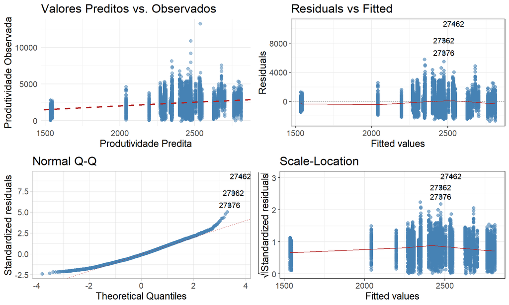

```r
# Cálculo matricial das predições
Y_pred <- X %*% betas

# Criando um data frame para o plot
df_residuos <- data.frame(Observado = as.numeric(Y),
                          Predito = as.numeric(Y_pred))

p0_lm.3 <- df_residuos |> ggplot(aes(x = Predito, y = Observado)) +
  geom_point(color = "steelblue", alpha = 0.5, size = 2) +
  geom_abline(intercept = 0, slope = 1, color = "firebrick", linetype = "dashed", size = 1) +
  labs(
    title = "Valores Preditos vs. Observados",
    x = "Produtividade Predita",
    y = "Produtividade Observada") +
  theme_minimal() +
  theme(text = element_text(size = 14))

## Gráficos do ajuste
p1_lm.3 <- autoplot(lm.3,
                    which = 1,
                    nrow = 1,
                    ncol = 1,
                    colour = 'steelblue',    # Cor dos pontos (resíduos)
                    smooth.colour = 'firebrick', # Cor da linha de tendência (curva)
                    ad.colour = 'grey50',    # Cor da linha horizontal de referência (zero)
                    size = 2,
                    line.size = 1,
                    alpha = 0.6) +
  theme_bw() +
  theme(text = element_text(size = 14))

p2_lm.3 <- autoplot(lm.3,
                    which = 2,
                    nrow = 1,
                    ncol = 1,
                    colour = 'steelblue',    # Cor dos pontos (observações)
                    ad.colour = 'firebrick', # Cor da linha de referência (Q-Q line)
                    ad.linetype = 'dashed',  # Estilo da linha
                    size = 2,                # Tamanho dos pontos
                    alpha = 0.6) +           # Transparência dos pontos
  theme_light() +
  theme(text = element_text(size = 14))

p3_lm.3 <- autoplot(lm.3,
                    which = 3,
                    nrow = 1,
                    ncol = 1,
                    colour = 'steelblue',       # Cor dos pontos (resíduos padronizados)
                    smooth.colour = 'firebrick',    # Cor da linha de tendência
                    ad.colour = 'grey50',       # Cor da linha de referência
                    size = 2,
                    alpha = 0.6) +
  theme_bw() +
  theme(text = element_text(size = 14))

grid.arrange(p0_lm.3, p1_lm.3[[1]], p2_lm.3[[1]], p3_lm.3[[1]] , ncol = 2)
```

A partir do modelo ajustado, obtém-se a seguinte equação de regressão:

$$\hat{y}_{ij} = 6542.654 - 205.563x_{i1} - 212.630x_{i2} + 0.347x_{i3}$$

em que $x_{i1}$ corresponde à latitude, $x_{i2}$ à longitude e $x_{i3}$ à elevação.

Considerando os coeficientes estimados:

- para cada aumento de uma unidade na latitude ($x_1$), espera-se um *decréscimo* médio de $205.563$ unidades na produtividade de grãos ($y$), mantendo-se constantes longitude ($x_2$) e elevação ($x_3$);
- para cada aumento de uma unidade na longitude ($x_2$), espera-se um *decréscimo* médio de $212.630$ unidades na produtividade de grãos ($y$), mantendo-se constantes latitude ($x_1$) e elevação ($x_3$);
- para cada metro adicional na elevação ($x_3$), espera-se um *aumento* médio de $0.347$ unidades na produtividade de grãos ($y$), mantendo-se constantes latitude ($x_1$) e longitude ($x_2$).

Todos os coeficientes estimados apresentaram elevada significância estatística ($p < 0.001$), indicando que as variáveis ambientais incluídas no modelo possuem associação significativa com a produtividade de grãos.

Para avaliar a significância global do modelo, foi realizado o teste:

$$H_0: \beta_1 = \beta_2 = \beta_3 = 0$$

contra a hipótese alternativa de que pelo menos um dos coeficientes seja diferente de zero.

O modelo apresentou parametros:

$$F = 88.6$$

e p-valor:

$$p < 2.2 \times 10^{-16}$$

Dessa forma, rejeita-se a hipótese nula $H_0$ ao nível de $5\%$ de significância, concluindo que pelo menos uma das variáveis ambientais avaliadas contribui significativamente para explicar a produtividade de grãos.

O coeficiente de determinação obtido foi:

$$R^2 = 0.03694$$

e o coeficiente de determinação ajustado:

$$R^2_{aj} = 0.03652$$

Esses resultados indicam que aproximadamente $3.65\%$ da variação observada na produtividade de grãos é explicada pelas variáveis ambientais incluídas no modelo. Embora os coeficientes tenham sido estatisticamente significativos, o baixo valor de $R^2$ sugere que grande parte da variabilidade da produtividade está associada a outros fatores não contemplados na análise, como manejo agrícola, fertilidade do solo, condições climáticas específicas e interação genótipo $\times$ ambiente.

O erro padrão residual estimado foi de aproximadamente:

$$\sigma = 1150$$

indicando a magnitude média dos desvios entre os valores observados e os valores preditos pelo modelo.

Analisando-se os gráficos, pode-se notar que existe interferência de outliers, principalmente na analise de normalidade dos resíduos. Vale também ressaltar, o comportamento discreto das leituras de latitude, longitude e altitude, Apesar de serem váriaveis continuas, o número limitado de ambientes levou a uma concentração das leituras em determinadas coordenadas, referentes à cada estação experimental. Apesar do comportamento incomum dos dados, não houve implicações deletérias no ajuste de modelo.

## Conclusão

A realização desta atividade possibilitou a aplicação prática de técnicas de regressão linear na análise de dados reais, proporcionando maior familiaridade com a base de dados utilizada no projeto final da disciplina. Além de consolidar os fundamentos teóricos relacionados aos modelos lineares, o desenvolvimento das análises permitiu aprofundar conhecimentos sobre ajuste de modelos, interpretação de coeficientes, avaliação de pressupostos e análise de resíduos.

O trabalho evidenciou a importância da regressão linear como ferramenta estatística para modelagem e interpretação de fenômenos biológicos. A atividade também contribuiu significativamente para o desenvolvimento da capacidade analítica e da resolução de problemas relacionados ao tratamento e interpretação de dados, especialmente diante das dificuldades práticas encontradas ao longo das etapas de análise. De modo geral, a experiência adquirida aqui tende a ser de grande utilidade ao longo da pós-graduação e também na futura atuação profissional dos membros envolvidos.